# Identification of Adolescents at Risk for Suicide Attempt

## SMOTE+TOMEK

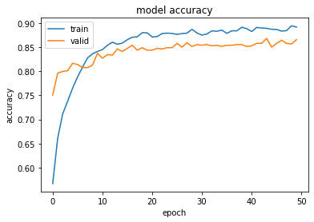

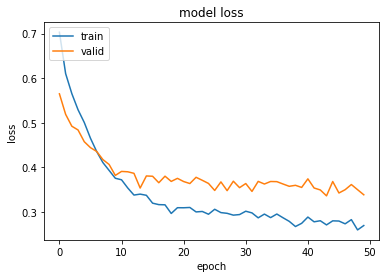

```
Loss is: 0.3221568465232849
Accuracy is: 0.8831437230110168
```

```python
seed_everything(1000)

model = model = tf.keras.Sequential([
        tf.keras.layers.Input(N_FEATURES),
        tf.keras.layers.BatchNormalization(),
        tf.keras.layers.Dropout(0.35),
        tfa.layers.WeightNormalization(tf.keras.layers.Dense(10, activation="relu")),
        tf.keras.layers.BatchNormalization(),
        tf.keras.layers.Dropout(0.35),
        tfa.layers.WeightNormalization(tf.keras.layers.Dense(1, activation="sigmoid"))
    ])

model.compile(optimizer=tf.keras.optimizers.Adam(learning_rate = 0.0001), loss='binary_crossentropy',
                  metrics=["accuracy"])

history=model.fit(x_stomek_nn,y_stomek_nn, epochs=50, batch_size=10, verbose=0,
                        validation_data=(x_valid_stomek,y_valid_stomek),shuffle=True)

# summarize history for accuracy
plt.plot(history.history['accuracy'])
plt.plot(history.history['val_accuracy'])
plt.title('model accuracy')
plt.ylabel('accuracy')
plt.xlabel('epoch')
plt.legend(['train', 'valid'], loc='upper left')
plt.show()

# summarize history for loss
plt.plot(history.history['loss'])
plt.plot(history.history['val_loss'])
plt.title('model loss')
plt.ylabel('loss')
plt.xlabel('epoch')
plt.legend(['train', 'valid'], loc='upper left')
plt.show()

final_model_eval=model.evaluate(x_test_df, y_test, batch_size=10)
print("Loss is:",final_model_eval[0])
print("Accuracy is:",final_model_eval[1])
```

```python
nn_predictions=model.predict(x_test_df)
```

```python
nn_predict(0.50)
nn_predict(0.40)
nn_predict(0.35)
nn_predict(0.30)
nn_predict(0.20)
nn_predict(0.15)
nn_predict(0.10)
nn_predict(0.05)
nn_predict(0.04)
nn_predict(0.03)
nn_predict(0.02)
nn_predict(0.015)
nn_predict(0.014)
nn_predict(0.013)
nn_predict(0.012)
```

```
Confusion matrix when threshold= 0.5
 [[844  85]
 [ 28  10]]
Sensitivity/recall when threshold = 0.5 : 0.2631578947368421
Specificity when threshold = 0.5 : 0.9085037674919269
Precision when threshold = 0.5 : 0.10526315789473684
F1 Score when threshold = 0.5 : 0.15037593984962405
Accuracy when threshold = 0.5 : 0.8831437435367114


Confusion matrix when threshold= 0.4
 [[819 110]
 [ 24  14]]
Sensitivity/recall when threshold = 0.4 : 0.3684210526315789
Specificity when threshold = 0.4 : 0.8815931108719053
Precision when threshold = 0.4 : 0.11290322580645161
F1 Score when threshold = 0.4 : 0.1728395061728395
Accuracy when threshold = 0.4 : 0.8614270941054809


Confusion matrix when threshold= 0.35
 [[807 122]
 [ 22  16]]
Sensitivity/recall when threshold = 0.35 : 0.42105263157894735
Specificity when threshold = 0.35 : 0.868675995694295
Precision when threshold = 0.35 : 0.11594202898550725
F1 Score when threshold = 0.35 : 0.18181818181818182
Accuracy when threshold = 0.35 : 0.8510858324715616


Confusion matrix when threshold= 0.3
 [[796 133]
 [ 22  16]]
Sensitivity/recall when threshold = 0.3 : 0.42105263157894735
Specificity when threshold = 0.3 : 0.8568353067814855
Precision when threshold = 0.3 : 0.10738255033557047
F1 Score when threshold = 0.3 : 0.17112299465240643
Accuracy when threshold = 0.3 : 0.8397104446742503


```

[output cut: 93 more lines]

```
Sensitivity/recall when threshold = 0.013 : 0.9210526315789473
Specificity when threshold = 0.013 : 0.35844994617868675
Precision when threshold = 0.013 : 0.0554675118858954
F1 Score when threshold = 0.013 : 0.10463378176382661
Accuracy when threshold = 0.013 : 0.38055842812823165


Confusion matrix when threshold= 0.012
 [[322 607]
 [  3  35]]
Sensitivity/recall when threshold = 0.012 : 0.9210526315789473
Specificity when threshold = 0.012 : 0.34660925726587727
Precision when threshold = 0.012 : 0.05451713395638629
F1 Score when threshold = 0.012 : 0.10294117647058823
Accuracy when threshold = 0.012 : 0.36918304033092036
```

# Future Steps

1) Consider additional classification methods

-I briefly explored random forest classification where working on this project. Given that this was very early exploration, the models are not shown, but I currently have similar sensitivity/specificity as the models shown above. I need to explore this more.

-I could also try other ensemble learning methods.

2) Consider alternate cost-sensitive learning strategies

-Alternate class weights

-Investigate alternate metrics (such as F2 score shown in figure below) to maximize sensitivity while limiting the impact on specificity

-Use parameter tuning functions to find hyperparameters that maximize sensitivity, F2 score, or another appropriate metric (GridSearchCV, etc.)

3) Consider variables other than adolescent self-reported factors

The figure below shows a decision tree to use to determine the best metric to evaluate models on during binary classification. Using this tool, I would like to investigate choosing my model using F2 score in future work. (Source: https://machinelearningmastery.com/framework-for-imbalanced-classification-projects/)

[figure not shown]

# Conclusions

The following summaries the performance of Hill et. al's classification tree model, my logistic regression with L1 regularization model, and my neural network model. As you can see, my models do not perform better than Hill et al.'s models and require additional unique pieces of information (20 features for the logistic regression model and the full dataset for the neural network). However, as I described in the "Future Steps" section above, additional research can be performed to investigate whether an alternate model may still be able to perform better than Hill et al.'s classification tree model to predict suicide attempts in a nationally representative sample of US youth.

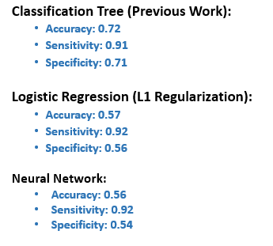